# Работа со списками: `purrr`

Г. Мороз

12/21/2019

[figure not shown]

```r
library(tidyverse)
```

## Что такое списки?

Допустим, вы забыли, что такое список:

```r
x <- list(m = "a", n = c(2, 4), o = c("blue", "green", "red"))
x
```

```
## $m
## [1] "a"
##
## $n
## [1] 2 4
##
## $o
## [1] "blue"  "green" "red"
```

```r
x$m
```

```
## [1] "a"
```

```r
x[1]
```

```
## $m
## [1] "a"
```

```r
x[[2]]
```

```
## [1] 2 4
```

```r
x[[2]][2]
```

```
## [1] 4
```

[figure not shown]

Списки вне R обычно хранят в файлах типа `.json` (по-английски говорят с ударением на первый слог, а вот по-русски прижился вариант с ударением на второй слог: джейсо́н) или `.xml` (мы обсудим только `.json`).

### Превращение JSON в список и обратно

Самое важное, что нужно знать, про `.json`, это то, что там могут хранится:

- пары ключ и значение, заключенные в фигурные скобки `{"ключ":"значение"}`
- упорядочные множества значений, заключенные в квадратные скобки `["значение_1","значение_2",...]`
- некоторые другие типы данных

Чтение и запись `.json` файлов осуществляется при помощи пакета `jsonlite` (не входит в `tidyverse`). Для примера скачаем датасет 30 героев Игры престолов, который Дж. Р. Р. Мартин достал с ресурса [An API of Ice And Fire](https://anapioficeandfire.com/).

```r
got_chars <- jsonlite::read_json("https://raw.githubusercontent.com/agricolamz/2019.12.21_EU_purrr/master/data/got_chars.json")
got_chars[1]
```

```
## [[1]]
## [[1]]$url
## [1] "https://www.anapioficeandfire.com/api/characters/1022"
##
## [[1]]$id
## [1] 1022
##
## [[1]]$name
## [1] "Theon Greyjoy"
##
## [[1]]$gender
## [1] "Male"
##
## [[1]]$culture
## [1] "Ironborn"
##
## [[1]]$born
## [1] "In 278 AC or 279 AC, at Pyke"
##
## [[1]]$died
## [1] ""
##
## [[1]]$alive
## [1] TRUE
##
## [[1]]$titles
## [[1]]$titles[[1]]
## [1] "Prince of Winterfell"
##
## [[1]]$titles[[2]]
## [1] "Captain of Sea Bitch"
##
## [[1]]$titles[[3]]
## [1] "Lord of the Iron Islands (by law of the green lands)"
##
##
## [[1]]$aliases
## [[1]]$aliases[[1]]
## [1] "Prince of Fools"
##
```

[output cut: 48 more lines]

```
## [[1]]$tvSeries[[3]]
## [1] "Season 3"
##
## [[1]]$tvSeries[[4]]
## [1] "Season 4"
##
## [[1]]$tvSeries[[5]]
## [1] "Season 5"
##
## [[1]]$tvSeries[[6]]
## [1] "Season 6"
##
##
## [[1]]$playedBy
## [1] "Alfie Allen"
```

Так как `jsonlite` конфликтует в одной функции с `tidyverse`, я не загружаю библиотеку полностью при помощи команды `library(jsonlite)`, а обращаюсь к функциям пакета при помощи выражения `jsonlite::...()`. Пакет `jsonlite` позволяет записывать `.json` файлы при помощи функции `write_json()`:

```r
jsonlite::write_json(got_chars, "got_chars.json", auto_unbox = TRUE)
# аргумент auto_unbox позволяет сохранять структуру, которую мы видим в R
```

### Просмотр списков в R

Просмоторщик списков встроен в RStudio. Его можно увидеть, если ткнуть в объект в R или написать команду `View(got_chars)`. Альтернативой может стать функция `jsonedit()` из пакета `listviewer`. Кроме того, что-то можно попробовать выяснить, используя функцию `str()`.

```r
str(got_chars[1])
```

```
## List of 1
##  $ :List of 18
##   ..$ url        : chr "https://www.anapioficeandfire.com/api/characters/1022"
##   ..$ id         : int 1022
##   ..$ name       : chr "Theon Greyjoy"
##   ..$ gender     : chr "Male"
##   ..$ culture    : chr "Ironborn"
##   ..$ born       : chr "In 278 AC or 279 AC, at Pyke"
##   ..$ died       : chr ""
##   ..$ alive      : logi TRUE
##   ..$ titles     :List of 3
##   .. ..$ : chr "Prince of Winterfell"
##   .. ..$ : chr "Captain of Sea Bitch"
##   .. ..$ : chr "Lord of the Iron Islands (by law of the green lands)"
##   ..$ aliases    :List of 4
##   .. ..$ : chr "Prince of Fools"
##   .. ..$ : chr "Theon Turncloak"
##   .. ..$ : chr "Reek"
##   .. ..$ : chr "Theon Kinslayer"
##   ..$ father     : chr ""
##   ..$ mother     : chr ""
##   ..$ spouse     : chr ""
##   ..$ allegiances: chr "House Greyjoy of Pyke"
##   ..$ books      :List of 3
##   .. ..$ : chr "A Game of Thrones"
##   .. ..$ : chr "A Storm of Swords"
##   .. ..$ : chr "A Feast for Crows"
##   ..$ povBooks   :List of 2
##   .. ..$ : chr "A Clash of Kings"
##   .. ..$ : chr "A Dance with Dragons"
##   ..$ tvSeries   :List of 6
##   .. ..$ : chr "Season 1"
##   .. ..$ : chr "Season 2"
##   .. ..$ : chr "Season 3"
##   .. ..$ : chr "Season 4"
##   .. ..$ : chr "Season 5"
##   .. ..$ : chr "Season 6"
##   ..$ playedBy   : chr "Alfie Allen"
```

```r
str(got_chars[1], max.level = 2)
```

```
## List of 1
##  $ :List of 18
##   ..$ url        : chr "https://www.anapioficeandfire.com/api/characters/1022"
##   ..$ id         : int 1022
##   ..$ name       : chr "Theon Greyjoy"
##   ..$ gender     : chr "Male"
##   ..$ culture    : chr "Ironborn"
##   ..$ born       : chr "In 278 AC or 279 AC, at Pyke"
##   ..$ died       : chr ""
##   ..$ alive      : logi TRUE
##   ..$ titles     :List of 3
##   ..$ aliases    :List of 4
##   ..$ father     : chr ""
##   ..$ mother     : chr ""
##   ..$ spouse     : chr ""
##   ..$ allegiances: chr "House Greyjoy of Pyke"
##   ..$ books      :List of 3
##   ..$ povBooks   :List of 2
##   ..$ tvSeries   :List of 6
##   ..$ playedBy   : chr "Alfie Allen"
```

## Пакет `purrr`

В `tidyverse` встроен пакет `purrr`, который среди прочего позволяет работать со списками. Существует [cheat sheet по `purrr`](https://github.com/rstudio/cheatsheets/raw/master/purrr.pdf).

### Функция `map()` и `map...()`

Можно выводить значения в списке на основе имени:

```r
got_chars %>%
  map("name")
```

```
## [[1]]
## [1] "Theon Greyjoy"
##
## [[2]]
## [1] "Tyrion Lannister"
##
## [[3]]
## [1] "Victarion Greyjoy"
##
## [[4]]
## [1] "Will"
##
## [[5]]
## [1] "Areo Hotah"
##
## [[6]]
## [1] "Chett"
##
## [[7]]
## [1] "Cressen"
##
## [[8]]
## [1] "Arianne Martell"
##
## [[9]]
## [1] "Daenerys Targaryen"
##
## [[10]]
## [1] "Davos Seaworth"
##
## [[11]]
## [1] "Arya Stark"
##
## [[12]]
## [1] "Arys Oakheart"
##
## [[13]]
## [1] "Asha Greyjoy"
##
## [[14]]
```

[output cut: 34 more lines]

```
##
## [[26]]
## [1] "Melisandre"
##
## [[27]]
## [1] "Merrett Frey"
##
## [[28]]
## [1] "Quentyn Martell"
##
## [[29]]
## [1] "Samwell Tarly"
##
## [[30]]
## [1] "Sansa Stark"
```

Можно выводить значения в списке на основе индекса:

```r
got_chars %>%
  map(3)
```

```
## [[1]]
## [1] "Theon Greyjoy"
##
## [[2]]
## [1] "Tyrion Lannister"
##
## [[3]]
## [1] "Victarion Greyjoy"
##
## [[4]]
## [1] "Will"
##
## [[5]]
## [1] "Areo Hotah"
##
## [[6]]
## [1] "Chett"
##
## [[7]]
## [1] "Cressen"
##
## [[8]]
## [1] "Arianne Martell"
##
## [[9]]
## [1] "Daenerys Targaryen"
##
## [[10]]
## [1] "Davos Seaworth"
##
## [[11]]
## [1] "Arya Stark"
##
## [[12]]
## [1] "Arys Oakheart"
##
## [[13]]
## [1] "Asha Greyjoy"
##
## [[14]]
```

[output cut: 34 more lines]

```
##
## [[26]]
## [1] "Melisandre"
##
## [[27]]
## [1] "Merrett Frey"
##
## [[28]]
## [1] "Quentyn Martell"
##
## [[29]]
## [1] "Samwell Tarly"
##
## [[30]]
## [1] "Sansa Stark"
```

Достаточно полезно знать о функции `unlist()`, которая “убивает” все сложную структуру:

```r
got_chars %>%
  map("name") %>%
  unlist()
```

```
##  [1] "Theon Greyjoy"      "Tyrion Lannister"   "Victarion Greyjoy"
##  [4] "Will"               "Areo Hotah"         "Chett"
##  [7] "Cressen"            "Arianne Martell"    "Daenerys Targaryen"
## [10] "Davos Seaworth"     "Arya Stark"         "Arys Oakheart"
## [13] "Asha Greyjoy"       "Barristan Selmy"    "Varamyr"
## [16] "Brandon Stark"      "Brienne of Tarth"   "Catelyn Stark"
## [19] "Cersei Lannister"   "Eddard Stark"       "Jaime Lannister"
## [22] "Jon Connington"     "Jon Snow"           "Aeron Greyjoy"
## [25] "Kevan Lannister"    "Melisandre"         "Merrett Frey"
## [28] "Quentyn Martell"    "Samwell Tarly"      "Sansa Stark"
```

Для этого есть и отдельные функции, которые позволяют превратить все в вектор заданного типа:

```r
got_chars %>%
  map_chr("name")
```

```
##  [1] "Theon Greyjoy"      "Tyrion Lannister"   "Victarion Greyjoy"
##  [4] "Will"               "Areo Hotah"         "Chett"
##  [7] "Cressen"            "Arianne Martell"    "Daenerys Targaryen"
## [10] "Davos Seaworth"     "Arya Stark"         "Arys Oakheart"
## [13] "Asha Greyjoy"       "Barristan Selmy"    "Varamyr"
## [16] "Brandon Stark"      "Brienne of Tarth"   "Catelyn Stark"
## [19] "Cersei Lannister"   "Eddard Stark"       "Jaime Lannister"
## [22] "Jon Connington"     "Jon Snow"           "Aeron Greyjoy"
## [25] "Kevan Lannister"    "Melisandre"         "Merrett Frey"
## [28] "Quentyn Martell"    "Samwell Tarly"      "Sansa Stark"
```

```r
got_chars %>%
  map_int("id")
```

```
##  [1] 1022 1052 1074 1109 1166 1267 1295  130 1303 1319  148  149  150  168 2066
## [16]  208  216  232  238  339  529  576  583   60  605  743  751  844  954  957
```

```r
got_chars %>%
  map_lgl("alive")
```

```
##  [1]  TRUE  TRUE  TRUE FALSE  TRUE FALSE FALSE  TRUE  TRUE  TRUE  TRUE FALSE
## [13]  TRUE  TRUE FALSE  TRUE  TRUE FALSE  TRUE FALSE  TRUE  TRUE  TRUE  TRUE
## [25] FALSE  TRUE FALSE FALSE  TRUE  TRUE
```

Можно даже создать новый датафрейм:

```r
got_chars %>%
  tibble(name = map_chr(., "name"), # точка обозначает, в какой аргумент должно все пайпиться
         id = map_dbl(., "id"),
         alive = map_lgl(., "alive"))
```

| . | name | id | alive |
| --- | --- | --- | --- |
|  | Theon Greyjoy | 1022 | TRUE |
|  | Tyrion Lannister | 1052 | TRUE |
|  | Victarion Greyjoy | 1074 | TRUE |
|  | Will | 1109 | FALSE |
|  | Areo Hotah | 1166 | TRUE |
|  | Chett | 1267 | FALSE |
|  | Cressen | 1295 | FALSE |
|  | Arianne Martell | 130 | TRUE |
|  | Daenerys Targaryen | 1303 | TRUE |
|  | Davos Seaworth | 1319 | TRUE |

[output cut: 20 more lines]

Также существует способ создание датафреймов на основе вектора значений при помощи функции `enframe()`:

```r
got_chars %>%
  map_chr("name") %>%
  enframe()
```

| name | value |
| --- | --- |
| 1 | Theon Greyjoy |
| 2 | Tyrion Lannister |
| 3 | Victarion Greyjoy |
| 4 | Will |
| 5 | Areo Hotah |
| 6 | Chett |
| 7 | Cressen |
| 8 | Arianne Martell |
| 9 | Daenerys Targaryen |
| 10 | Davos Seaworth |

[output cut: 20 more lines]

#### Задание 1

Скачайте [частотный словарь русского языка [Шаров, Ляшевская 2011] (он храниться в `.tsv`)](https://raw.githubusercontent.com/agricolamz/DS_for_DH/master/data/freq_dict_2011.csv), разбейте столбец `lemma` на буквы при помощи функции `str_split(dict$lemma, "")`, а на основе полученного списка постройте график, на котором изображено, сколько раз встретилась какая буква:

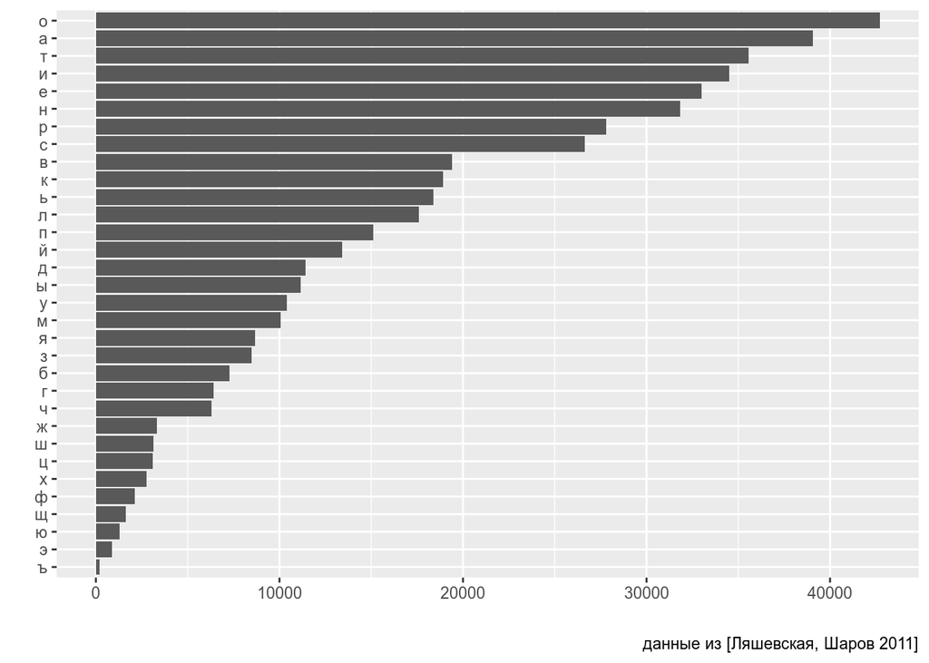

**📋 список подсказок ➡**

**👁 `tidyverse` включили? ➡**

`library(tidyverse)`.

**👁 `.tsv`? Почему словарь скачивается как один столбец? ➡**

`.tsv` — это как `.csv`, только в качестве разделителя не запятая, а табуляция (`\t`). Попробуйте использовать другой разделитель или функцию `read_tsv()` из пакета `readr` (входит в `tidyverse`).

**👁 Почему словарь как-то криво скачивается? ➡**

Cкорее всего полетела кодировка. Я все делаю в UTF-8, так что либо поменяйте кодировку в функции, которую Вы используете, либо исполбзуйте функцию `read_tsv()` из пакета `readr` (входит в `tidyverse`) — она сама борется с кодировками.

**👁 Получился список. А-а-а-а! Как его убрать? ➡**

Это простой случай, так что в каком-то смысле списочная структура не очень нужна. Так что можно просто `unlist()`.

**👁 Я получил вектор. А что дальше? ➡**

В принципе, график `ggplot2` требует на вход датафрейм, так что его можно сделать при помощи чего угодно. Я использовал `enframe()`.

**👁 Какие-то буквы большие, какие-то маленькие… Что делать? ➡**

Существует много способов привести все к строчным буквам: `tolower("ВАША СТРОКА")` из базого R, или `str_to_lower()` из пакета `stringr` (входит в `tidyverse`).

**👁 А как убрать дефис и апостроф? ➡**

Ну во-первых, что-то нужно убрать, а что-то оставить — значит нужна функция `filter()` из пакета `dplyr`. А дальше уже вопрос техники: можно использовать констуркцию `value != "-"`. А можно убить двух зайцев одним выстрелом и использовать регулярку: `filter(str_detect(value, "\\w"))`.

**👁 А как посчитать кого сколько? ➡**

Для этого можно использовать функцию `count()`. Можно было вообще не считать и использовать `geom_bar()`, но тогда не получиться отсортировать по возрастанию.

**👁 А какой `geom_` использовать? ➡**

Я использовал `geom_col()`. Можно еще использовать `geom_bar()` на неагрегированных данных, но тогда не удастся отсортировать.

**👁 А как перевернуть оси? ➡**

Добавьте `coord_flip()` к объекту `ggplot`.

**👁 А как отсортировать по возрастанию? ➡**

Для этого нужно превратить переменную в фактор с правильным порядком. Я это обычно делаю при помощи функции `fct_reorder()` из пакета `forcats` (входит в `tidyverse`) уже в `ggplot()`: `data %>% ggplot(aes(x = fct_reorder(value, n), y = n)) + ...`.

#### Задание 2 (домой)

В датасете, собранный [Adithya Ganesh](https://www.kaggle.com/adithyarganesh/english-premier-league-player-data-20182019#fpl_data_2018_2019.json), хранится информация об играках Английской Премьер-лиги. На основании этих данных (лежат в папке `data`) постройте график 30 игроков, которые забили больше всего голов и раскрасьте на основании их футбольного клуба.

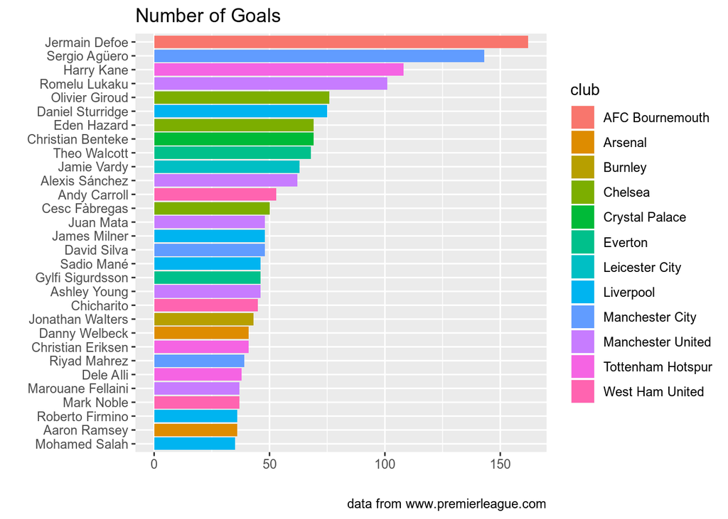

### Фильтрация списков

Если в списке есть логические выражения, их можно использовать как фильтры. Например, вот так мы оставим только живых героев:

```
##  [1] "Theon Greyjoy"      "Tyrion Lannister"   "Victarion Greyjoy"
##  [4] "Areo Hotah"         "Arianne Martell"    "Daenerys Targaryen"
##  [7] "Davos Seaworth"     "Arya Stark"         "Asha Greyjoy"
## [10] "Barristan Selmy"    "Brandon Stark"      "Brienne of Tarth"
## [13] "Cersei Lannister"   "Jaime Lannister"    "Jon Connington"
## [16] "Jon Snow"           "Aeron Greyjoy"      "Melisandre"
## [19] "Samwell Tarly"      "Sansa Stark"
```

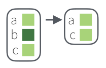

```r
got_chars %>%
  keep("alive") %>%
  map_chr("name")
```

А так – только мертвых:

```
##  [1] "Will"            "Chett"           "Cressen"         "Arys Oakheart"
##  [5] "Varamyr"         "Catelyn Stark"   "Eddard Stark"    "Kevan Lannister"
##  [9] "Merrett Frey"    "Quentyn Martell"
```

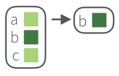

```r
got_chars %>%
  discard("alive") %>%
  map_chr("name")
```

Также есть особый фильтр `head_while()` и `tail_while()`, который выделяет единицы (с начала и конца) до первого `FALSE`.

```r
got_chars %>%
  head_while("alive") %>%
  map_chr("name")
```

```
## [1] "Theon Greyjoy"     "Tyrion Lannister"  "Victarion Greyjoy"
```

```
## [1] "Samwell Tarly" "Sansa Stark"
```

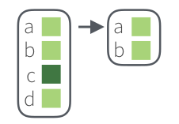

```r
got_chars %>%
  tail_while("alive") %>%
  map_chr("name")
```

Если все еще не понятно, взгляните на нашу таблицу:

```r
got_chars %>%
  tibble(name = map_chr(., "name"), # точка обозначает, в какой аргумент должно все пайпиться
         alive = map_lgl(., "alive"))
```

| . | name | alive |
| --- | --- | --- |
|  | Theon Greyjoy | TRUE |
|  | Tyrion Lannister | TRUE |
|  | Victarion Greyjoy | TRUE |
|  | Will | FALSE |
|  | Areo Hotah | TRUE |
|  | Chett | FALSE |
|  | Cressen | FALSE |
|  | Arianne Martell | TRUE |
|  | Daenerys Targaryen | TRUE |
|  | Davos Seaworth | TRUE |

[output cut: 20 more lines]

### Операции со списками

Рассмотрим простой пример:

```r
my_l <- list(a = 1:3, b = c("a", "b"), c = list("z", c(8, 9)))
my_l
```

```
## $a
## [1] 1 2 3
##
## $b
## [1] "a" "b"
##
## $c
## $c[[1]]
## [1] "z"
##
## $c[[2]]
## [1] 8 9
```

Как уже говорилось выше, функция `unlist()` линеаризует списки, превращая их в векторы:

```r
my_l %>%
  unlist()
```

```
##  a1  a2  a3  b1  b2  c1  c2  c3
## "1" "2" "3" "a" "b" "z" "8" "9"
```

Получился поименнованный вектор, если этого недостаточно, можно уничтожить и имена при помощи функции `unname()`:

```r
my_l %>%
  unlist() %>%
  unname()
```

```
## [1] "1" "2" "3" "a" "b" "z" "8" "9"
```

Функция `flatten` позволяет уничтожить **лишь один, верхний,**, уровень иерархии:

```r
my_l %>%
  flatten()
```

```
## [[1]]
## [1] 1
##
## [[2]]
## [1] 2
##
## [[3]]
## [1] 3
##
## [[4]]
## [1] "a"
##
## [[5]]
## [1] "b"
##
## [[6]]
## [1] "z"
##
## [[7]]
## [1] 8 9
```

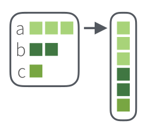

Как видно из этого примера, первый элемент списка `my_l` превратился в три первых элемента списка, а вот подсписок `c = list("z", c(8, 9))` превратился в элемент `z` и вектор `c(8, 9)`.

Существуют также функции `append()` и `prepend()`, которые позволяют добавлять новый посписок после (или до) старого:

```r
list(c(1, 2), c("a", "b", "c")) %>%
  append(list(new = c(TRUE, FALSE)))
```

```
## [[1]]
## [1] 1 2
##
## [[2]]
## [1] "a" "b" "c"
##
## $new
## [1]  TRUE FALSE
```

```r
list(c(1, 2), c("a", "b", "c")) %>%
  prepend(list(new = c(TRUE, FALSE)))
```

```
## $new
## [1]  TRUE FALSE
##
## [[2]]
## [1] 1 2
##
## [[3]]
## [1] "a" "b" "c"
```

Существует также функции `cross()` и `cross2()`, которые позволяют получить уникальные комбинации объектов из двух списков:

```r
list(c("a", "b"), 1:3) %>%
  cross() %>%
  str()
```

```
## List of 6
##  $ :List of 2
##   ..$ : chr "a"
##   ..$ : int 1
##  $ :List of 2
##   ..$ : chr "b"
##   ..$ : int 1
##  $ :List of 2
##   ..$ : chr "a"
##   ..$ : int 2
##  $ :List of 2
##   ..$ : chr "b"
##   ..$ : int 2
##  $ :List of 2
##   ..$ : chr "a"
##   ..$ : int 3
##  $ :List of 2
##   ..$ : chr "b"
##   ..$ : int 3
```

```r
list("a", "b") %>%
  cross2(1:3) %>%
  str()
```

```
## List of 6
##  $ :List of 2
##   ..$ : chr "a"
##   ..$ : int 1
##  $ :List of 2
##   ..$ : chr "b"
##   ..$ : int 1
##  $ :List of 2
##   ..$ : chr "a"
##   ..$ : int 2
##  $ :List of 2
##   ..$ : chr "b"
##   ..$ : int 2
##  $ :List of 2
##   ..$ : chr "a"
##   ..$ : int 3
##  $ :List of 2
##   ..$ : chr "b"
##   ..$ : int 3
```

## Ребрендинг функции `map()`

© G. Moroz code on [GitHub](https://github.com/agricolamz/2019.12.21_EU_purrr)